# III. Functional classification of differentially expressed genes

# 1 Preparation

**Libraries/utils:**

```r
if (!require("librarian")) install.packages("librarian")
# data
librarian::shelf(
  dplyr, tidyr, stringr, purrr,
  org.Dm.eg.db, biomaRt, DOSE, fgsea, clusterProfiler, gage,
  ggh4x, ggthemes, ggtext, ggrepel, ggnewscale,
  enrichplot, genekitr, pathview,  cetcolor, patchwork,
  here, quiet=TRUE)

if(!exists("gseCP_summarise", mode="function")) source("utils.R")
```

**Set working directory:**

```r
if (Sys.getenv("RSTUDIO")==1) {
   # setwd to where the editor is, if the IDE is RStudio
  setwd( dirname(rstudioapi::getSourceEditorContext(id = NULL)$path) )
} else {
  # setwd to where the editor is in a general way - maybe less failsafe than the previous
  setwd(here::here())
  # the following checks that the latter went well, but assuming
  # that the user has not changed the name of the repo
  d <- str_split(getwd(), fsep)[[1]][length(str_split(getwd(), fsep)[[1]])]
  if (d != 'Puigetal2023_bioinformatics_scripts') { stop(
    paste0("Could not set working directory automatically to where this",
           " script resides.\nPlease do `setwd()` manually"))
    }
}
```

**To save images outside the repo (to reduce size):**

```r
## to keep it lightweight for GitHub:
# figdir <- paste0(c(head(str_split(getwd(), fsep)[[1]],-1),
#                    paste0(tail(str_split(getwd(), fsep)[[1]],1), '_figures')),
#                  collapse = fsep)
# dir.create(figdir, showWarnings = FALSE)

## for Zenodo:
figdir <- file.path(getwd(), 'figures')
dir.create(figdir, showWarnings = FALSE)
```

Load DGE data from `DESeq2`:

```r
# experimental design and labels
targets <- readRDS(file.path('output', 'targets.RDS'))
# DEG data
DaDaOE_deg <- readRDS(file.path('output', 'Control_vs_DaDaOE.RDS'))
DaKD_deg <- readRDS(file.path('output', 'Control_vs_DaKD.RDS'))
DaOE_deg <- readRDS(file.path('output', 'Control_vs_DaOE.RDS'))
ScOE_deg <- readRDS(file.path('output', 'Control_vs_ScOE.RDS'))
```

# 2 Gene set enrichment analysis of custom gene sets

I run GSEA using the wrapper from the `clusterProfiler` package, which is based (with our options) on `fsgea`. Running GSEA (or over-representation using hypergeometric tests) on Gene Ontologies was not very informative, so I turn to custom lists.

## 2.1 Cell-type specific transcriptomes

Dutta et al. (2015) developed the methods for FACS-purifying different cell types in the adult midgut, and applied them to characterise the transcriptional profiles of ISCs, EBs, EEs and ECs ([doi:10.1016/j.celrep.2015.06.009](https://pubmed.ncbi.nlm.nih.gov/26146076)). I will use these profiles as gene sets to characterise the ‘identity’ imparted by our genetic perturbations of *da* and *sc*.

#### Run GSEA

I first load the GMX file storing the gene sets identified in Dutta et al. (2015) and run `clusterProfiler::GSEA`:

```r
dutta_gmx <- import_from_gmx(file.path(getwd(), 'resources', 'GMX', 'Dutta.gmx'))

daKD_gse_dutta <- GSEA(geneList=make_degrank(DaKD_deg, mode='log2fc', key='ensemblGeneID'),
                       exponent = 1,
                       minGSSize = 1,
                       maxGSSize = 1000,
                       eps = 0,
                       pvalueCutoff = 1,
                       pAdjustMethod = "BH",
                       TERM2GENE = dutta_gmx,
                       TERM2NAME = NA,
                       verbose = TRUE,
                       seed = FALSE,
                       by = "fgsea")

daOE_gse_dutta <- GSEA(geneList=make_degrank(DaOE_deg, mode='log2fc', key='ensemblGeneID'),
                       exponent = 1,
                       minGSSize = 1,
                       maxGSSize = 1000,
                       eps = 0,
                       pvalueCutoff = 1,
                       pAdjustMethod = "BH",
                       TERM2GENE = dutta_gmx,
                       TERM2NAME = NA,
                       verbose = TRUE,
                       seed = FALSE,
                       by = "fgsea")

dadaOE_gse_dutta <- GSEA(geneList=make_degrank(DaDaOE_deg, mode='log2fc', key='ensemblGeneID'),
                       exponent = 1,
                       minGSSize = 1,
                       maxGSSize = 1000,
                       eps = 0,
                       pvalueCutoff = 1,
                       pAdjustMethod = "BH",
                       TERM2GENE = dutta_gmx,
                       TERM2NAME = NA,
                       verbose = TRUE,
                       seed = FALSE,
                       by = "fgsea")

scOE_gse_dutta <- GSEA(geneList=make_degrank(ScOE_deg, mode='log2fc', key='ensemblGeneID'),
                       exponent = 1,
                       minGSSize = 1,
                       maxGSSize = 1000,
                       eps = 0,
                       pvalueCutoff = 1,
                       pAdjustMethod = "BH",
                       TERM2GENE = dutta_gmx,
                       TERM2NAME = NA,
                       verbose = TRUE,
                       seed = FALSE,
                       by = "fgsea")
```

#### Layered heatmap to display NES across conditions and sets

I prepare the GSEA results to plot them as heatmaps with *NES* as coloured tiles and adjusted *p*-value as coloured marks with the custom functions `gseCP_summarise` and `layer.heatmap`.

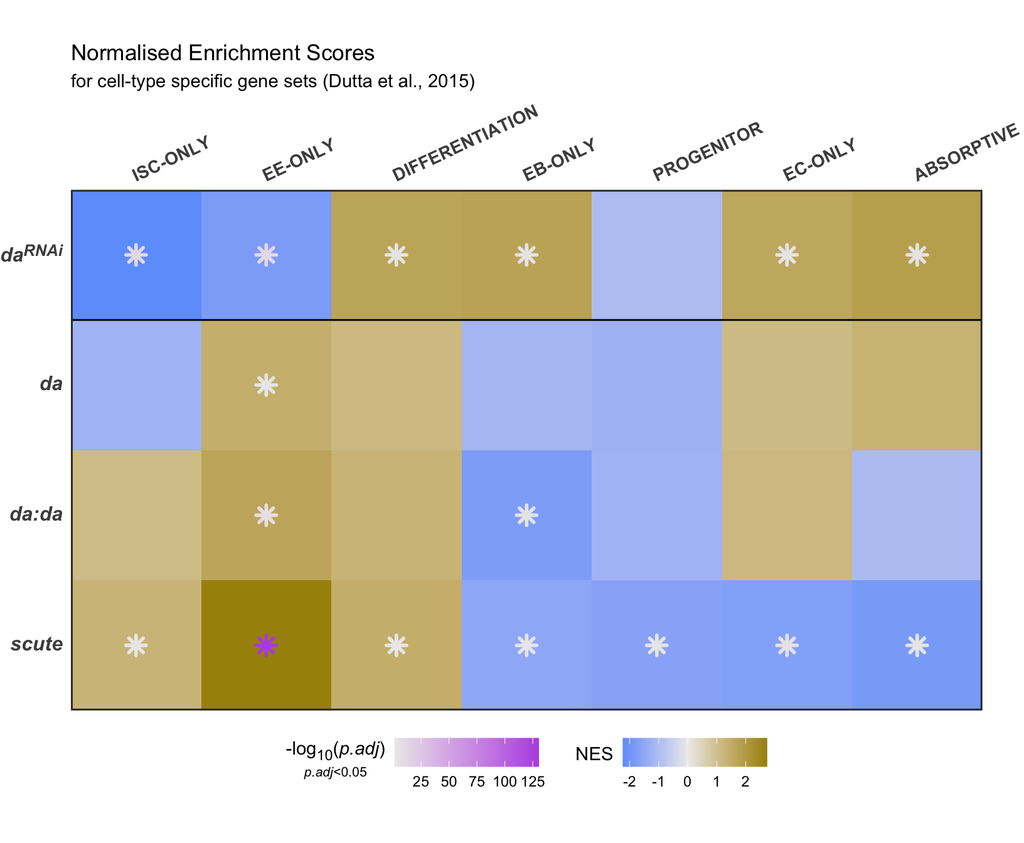

```r
gse_list <- list(scOE_gse_dutta, dadaOE_gse_dutta, daOE_gse_dutta, daKD_gse_dutta)
conditions <- c('*scute*', '*da:da*', '*da*', '*da^RNAi^*') # in markdown to be used later as plot labels
# gse_list and conditions must have the same order
sets.as.factors <- c("ISC-only", "Progenitor", "EB-only", "EE-only",
                     "Absorptive", "EC-only", "Differentiation")
layerhm.df <- gseCP_summarise(dutta_gmx, gse_list, conditions, sets.as.factors,
                          cluster=TRUE, nsig.out = FALSE)
subt <- "for cell-type specific gene sets (Dutta et al., 2015)"
p <- layer.heatmap(layerhm.df, subt)
p <- p + geom_hline(aes(yintercept=3.5), linewidth = 0.5) +
  theme(plot.margin = margin(r = 25))
p
```

#### GSEA plots

Now we need to make enrichment score plots from the results. We use `genekitr` for this, which requires a conversion from `clusterProfiler` output.

```r
# specify the organism in the clusterProfiler gsea S4 objects:
# daKD_gse_dutta, daOE_gse_dutta, dadaOE_gse_dutta, scOE_gse_dutta
daKD_gse_dutta@organism <- 'dm'
daOE_gse_dutta@organism <- 'dm'
dadaOE_gse_dutta@organism <- 'dm'
scOE_gse_dutta@organism <- 'dm'
# converting clusterProfiler gsea objects to genekitr structures
daKD_gse_dutta_gtr   <- importCP(daKD_gse_dutta, type = 'gsea')
daOE_gse_dutta_gtr   <- importCP(daOE_gse_dutta, type = 'gsea')
dadaOE_gse_dutta_gtr <- importCP(dadaOE_gse_dutta, type = 'gsea')
scOE_gse_dutta_gtr   <- importCP(scOE_gse_dutta, type = 'gsea')
```

We want to compare the effect of overexpressing Da:Da or Scute on EE or ISC genes, and specifically on some genes that are related to cell cycle progression.

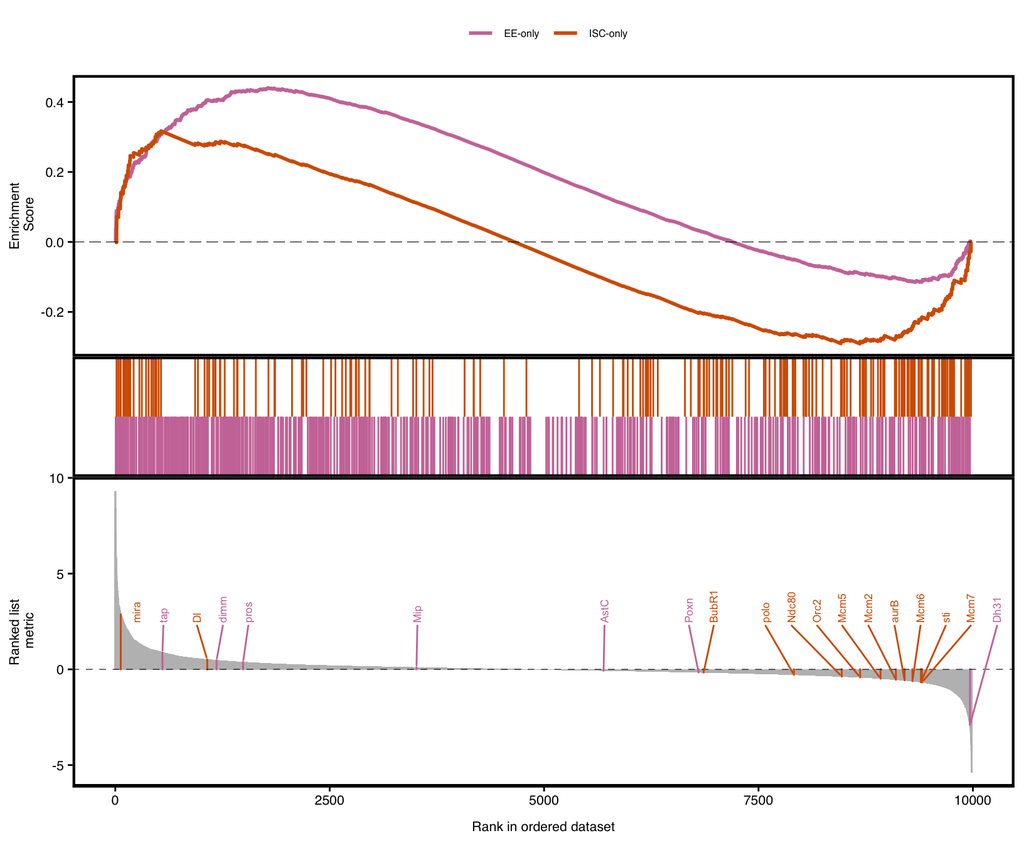

```r
genes2show <- c('pros', 'poxn', 'mira', 'spdo', 'polo', 'cdk1', 'Myo31DF', 'ck', 'nub', 'sti', 'Mcm2', 'Orc2', 'Mcm7', 'Mcm5', 'aurB', 'Mcm6', 'Ndc80', 'PolE2', 'BubR1', 'betaTry', 'iotaTry', 'alphaTry', 'AstA', 'Mip', 'AstB', 'AstC', 'tk', 'dimm', 'tap', 'Dl', 'Poxn', 'Dh31')
cellcolours <- c('#CC79A7', '#D55E00')
p <- plotGSEA(dadaOE_gse_dutta_gtr,
              plot_type = "classic",
              show_pathway = c("EE-only", "ISC-only"),
              colour = cellcolours,
              show_gene = genes2show)
```

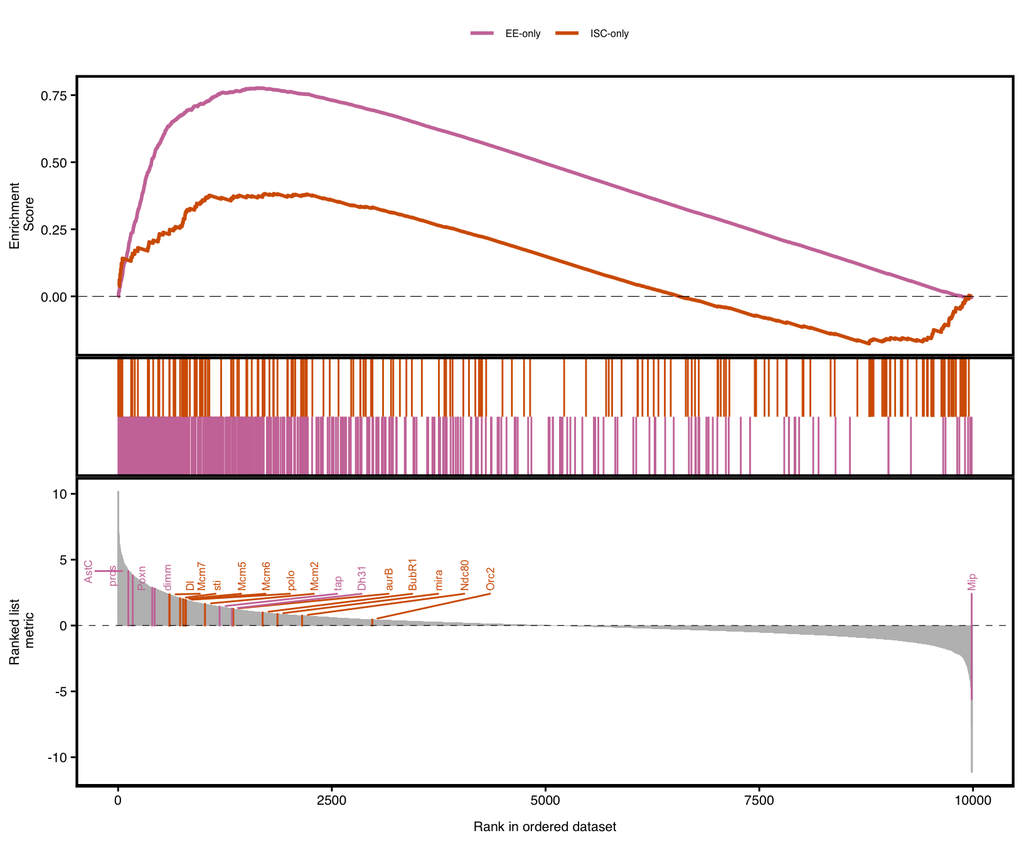

```r
q <- plotGSEA(scOE_gse_dutta_gtr,
              plot_type = "classic",
              show_pathway = c("EE-only", "ISC-only"),
              colour = cellcolours,
              show_gene = genes2show)
```

## 2.2 Gene List Annotation for Drosophila

GLAD (*Gene List Annotation for Drosophila*) was developed as an annotation effort that builds on Gene Ontology classifications but has a few added layers of curation (e.g. manual annotation by experts; Hu et al., 2015). It is also much more lightweight than GO. These features make it especially valuable for interpreting the enrichment in functional annotation terms.

#### Prepare the data

GLAD offers only two levels of gene set organisations: the main lists, and one additional sub-classification that is not present in all classes. The sub-level of classification can have two parallel options: for instance, the main group *Transcription Factors/DNA binding* could be subdivided by molecular function (*DNA-binding with transcription factor activity*, *Co-factor*, *Chromatin regulation*, etc.), or by molecular structure (*bHLH*, *Zf-C2H2*, *Homeobox*, etc.). Of these, the only one I will be looking into is the different signalling pathways that subdivide the *Major signalling pathways* annotation term.

The GLAD resource files were downloaded from https://www.flyrnai.org/tools/glad/web.

```r
# read whole dataset from file collection
gladdir <- file.path(getwd(), 'resources', 'GLAD')
gladfiles <- paste(gladdir, list.files(gladdir), sep=fsep)
names(gladfiles) <- lapply (
  gladfiles,
  \(x) str_split(str_split(x, "GLAD_")[[1]][[2]], '_')[[1]][[1]] )
read.add <- function(csv, csvlist) {
  df <- read.csv(csv)
  df$term <- names(which(csvlist==csv))
  return(df)
}
datas <- lapply(gladfiles, \(x) read.add(x, gladfiles))
glad_dataset <- do.call(rbind , c(datas, make.row.names=FALSE))
```

Clean up the strings for term names for the plot:

```r
substitutions <- c(' signaling pathway$'='',
                   '\\.'=' ',
                   'Co '='Co-',
                   'Non '='Non-',
                   'RTK| RTK'='',
                   "DNA "="DNA-",
                   "TNF "="TNF-",
                   "TGF "="TGF-",
                   ' and '=' / ',
                   'transcription factor|Transcription factor'='TF',
                   ':'='/',
                   '^HLH'='bHLH',
                   '^Basic'='b',
                   '\\|'='')
glad_dataset <- glad_dataset %>%
  # remove 1-2-1 substitutions above
  dplyr::mutate(across(c(term, Sub.group, Sub.sub.group),
                \(x) str_replace_all(x, substitutions))) %>%
  # remove trailing spaces
  dplyr::mutate(across(c(term, Sub.group, Sub.sub.group),
                \(x) str_replace_all(x, '  $| $', ''))) %>%
  # start all strings with Uppercase
  dplyr::mutate(across(c(term, Sub.group, Sub.sub.group),
                \(x) gsub(x, pattern="(^[[:lower:]])", replacement="\\U\\1", perl=TRUE))) %>%
  # substitute empty strings for NAs
  dplyr::mutate_at(c('term', 'Sub.group', 'Sub.sub.group'), ~na_if(., ''))
```

Establish the gene sets in tidy dataframes (subdivisions are in lists):

```r
# major groups
glad_gmx <- glad_dataset %>%
  dplyr::select(term, FBgn) %>%
  dplyr::rename(gene = FBgn)

# subgroups that contain the signalling pathways
glad_sub_gmx <- refine_glad_by(glad_dataset, 'Sub.group')
```

### Run GSEA, main terms

GSEA calls, major lists:

```r
# common parameters
GSEAparams <- list(
  exponent = 1,
  minGSSize = 1,
  maxGSSize = 5000,
  eps = 0,
  pvalueCutoff = 1,
  pAdjustMethod = "BH",
  TERM2NAME = NA,
  verbose = TRUE,
  seed = FALSE,
  by = "fgsea"
  )

# da knockdown
rank_dakd <- make_degrank(DaKD_deg, mode='log2fc', key='ensemblGeneID')
daKD_gse_glad <- do.call(
  GSEA, c(list(geneList=rank_dakd, nPermSimple = 1000, TERM2GENE = glad_gmx), GSEAparams)
  )
# da overexpression
rank_da <- make_degrank(DaOE_deg, mode='log2fc', key='ensemblGeneID')
daOE_gse_glad <- do.call(
  GSEA, c(list(geneList=rank_da, nPermSimple = 1000, TERM2GENE = glad_gmx), GSEAparams)
  )
# da:da overexpression
rank_dada <- make_degrank(DaDaOE_deg, mode='log2fc', key='ensemblGeneID')
dadaOE_gse_glad <- do.call(
  GSEA, c(list(geneList=rank_dada, nPermSimple = 10000, TERM2GENE = glad_gmx), GSEAparams)
  )
# scute overexpression
if ( !file.exists(file.path('output', 'scOE_gse_glad.RDS')) ) {
  rank_sc <- make_degrank(ScOE_deg, mode='log2fc', key='ensemblGeneID')
  # nPermSimple = 1000000 is needed to calculate accurate p-values
  # this takes a while so I only do it the fist time I run the script
  # then save the results in case I run it later with modifications
  scOE_gse_glad <- do.call(
    GSEA, c(list(geneList=rank_sc, nPermSimple = 1000000, TERM2GENE = glad_gmx), GSEAparams)
    )  # <|-------------------------------------- this step will take ~1h
  saveRDS(scOE_gse_glad, file.path('output', 'scOE_gse_glad.RDS'))
} else scOE_gse_glad <- readRDS(file.path('output', 'scOE_gse_glad.RDS'))
```

#### Layered heatmaps, main terms

Organise GSEA results and plot as “layered” heatmaps:

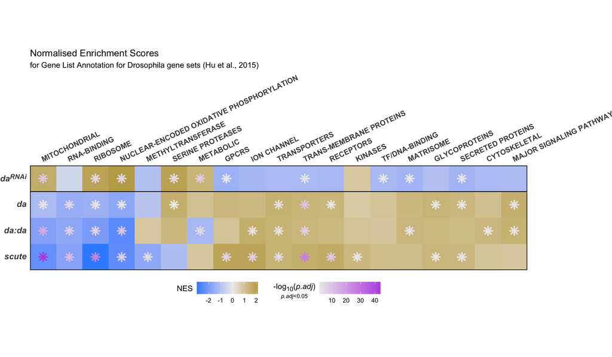

```r
# prepare data
gse_list <- list(scOE_gse_glad, dadaOE_gse_glad, daOE_gse_glad, daKD_gse_glad)
# `conditions` was defined further above
sets.as.factors <- unique(glad_gmx$term)
layerhm.df <- gseCP_summarise(glad_gmx, gse_list, conditions, sets.as.factors,
                              cluster = TRUE, nsig.out = TRUE)

# remove 2nd version of Metabolic genes - it is redundant
layerhm.df <- layerhm.df %>%
  filter(ID != 'Metabolic vs2')
layerhm.df$ID <- forcats::fct_drop(layerhm.df$ID, only = 'Metabolic vs2')

# plot
subt <- "for Gene List Annotation for Drosophila gene sets (Hu et al., 2015)"
p <- layer.heatmap(layerhm.df, subt)
p + geom_hline(aes(yintercept=3.5), linewidth = 0.5) +
  theme(plot.margin = margin(r = 120))
```

```r
ggsave(file.path(figdir, 'GSEA_GLAD1.pdf'))
```

#### Run GSEA, Major signalling pathways

Now let’s produce the gsea for the sub-terms of *Major signalling pathways*:

```r
daKD_gse_sigpath   <- subglad_gsea(DaKD_deg, glad_sub_gmx['Major signaling pathways'], perm = 10000)
daOE_gse_sigpath   <- subglad_gsea(DaOE_deg, glad_sub_gmx['Major signaling pathways'], perm = 10000)
dadaOE_gse_sigpath <- subglad_gsea(DaDaOE_deg, glad_sub_gmx['Major signaling pathways'], perm = 10000)
scOE_gse_sigpath   <- subglad_gsea(ScOE_deg, glad_sub_gmx['Major signaling pathways'], perm = 10000)
```

#### Layered heatmaps, Major signalling pathways

Same routine as above:

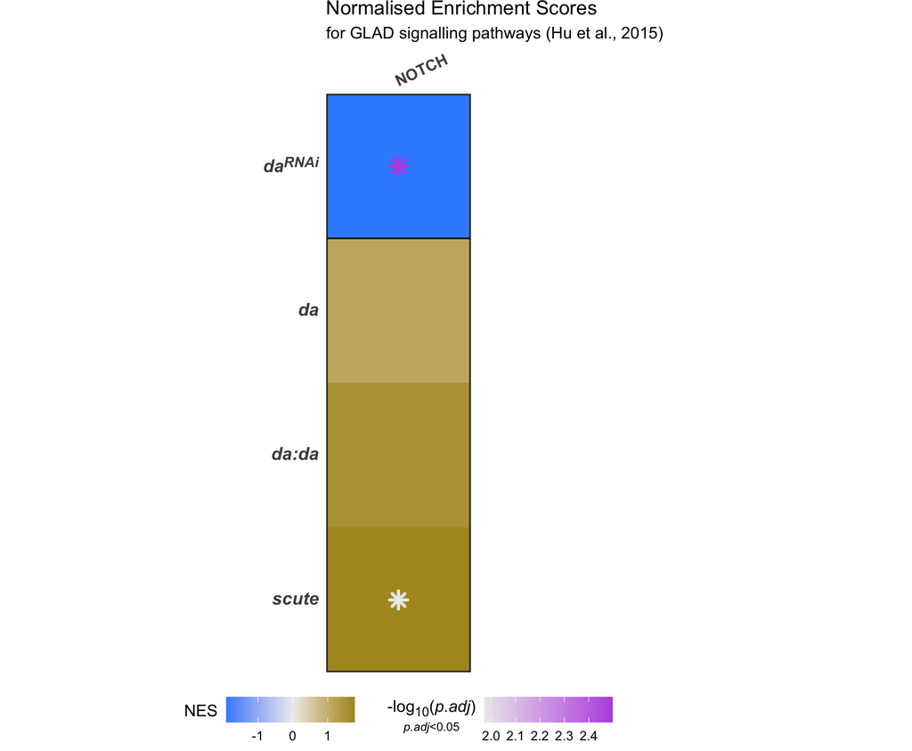

```r
gse_list <- list(scOE_gse_sigpath$`Major signaling pathways`,
                 dadaOE_gse_sigpath$`Major signaling pathways`,
                 daOE_gse_sigpath$`Major signaling pathways`,
                 daKD_gse_sigpath$`Major signaling pathways`)
# `conditions` was defined further above
sets.as.factors <- unique(glad_sub_gmx$`Major signaling pathways`$term)
layerhm.df <- gseCP_summarise(glad_sub_gmx,
                              gse_list, conditions, sets.as.factors,
                              cluster = FALSE, nsig.out = TRUE)
subt <- "for GLAD signalling pathways (Hu et al., 2015)"
p <- layer.heatmap(layerhm.df, subt)
p + geom_hline(aes(yintercept=3.5), linewidth = 0.5) +
  theme(plot.margin = margin(r = 120))
```

```r
ggsave(file.path(figdir, 'GSEA_notch.pdf'))
```

# 3 Metabolic signatures using KEGG

## 3.1 Collect NCBI gene IDs to match KEGG database

The KEGG database has all their set members identified with the NCBI gene IDs (a.k.a. ‘entrez gene ID’). We have ensembl IDs and gene symbols, so we need to retrieve the *Drosophila* NCBI identifiers:

```r
ensembl <- useEnsembl(biomart = "ENSEMBL_MART_ENSEMBL",
                     dataset="dmelanogaster_gene_ensembl",
                     host = "https://oct2022.archive.ensembl.org")
attributes <- listAttributes(ensembl)
ids <- c('entrezgene_id', 'ensembl_gene_id', 'external_gene_name')
ezlist <- getBM(attributes=ids, mart = ensembl)
ezlist <- drop_na(ezlist)
```

This gets us the KEGG sets for *Drosophila*:

```r
kegg.sets.dme <- kegg.gsets(species='dme', id.type='entrez')
```

KEGG *signalling* pathways do not show anything that has not been already indicated by GLAD or GO, so we focus on *metabolic* pathways:

```r
# separate sig.naling vs met.abolic pathways and tidy them up
kegg.met_tidy <- NULL
KMET <- kegg.sets.dme$kg.sets[kegg.sets.dme$met.idx]
for ( x in 1:length(KMET) ) {
  df <- data.frame(gene = KMET[[x]])
  df$term <- names(KMET)[[x]]
  kegg.met_tidy <- rbind(kegg.met_tidy, dplyr::select(df, term, gene))
}
# split term names into KEGG ID and description
kegg.met_tidy <- kegg.met_tidy %>%
  separate_wider_delim(term, ' ', names = c('term', 'description'),
                       too_many = 'merge')
kegg.met_tidy[as.integer(seq(from=1, to=nrow(kegg.met_tidy), length.out = 10)),]
```

| term | description | gene |
| --- | --- | --- |
| dme00010 | Glycolysis / Gluconeogenesis | 45880 |
| dme00190 | Oxidative phosphorylation | 5740185 |
| dme00350 | Tyrosine metabolism | 38746 |
| dme00531 | Glycosaminoglycan degradation | 34544 |
| dme00730 | Thiamine metabolism | 42482 |
| dme00983 | Drug metabolism - other enzymes | 37960 |
| dme01100 | Metabolic pathways | 43369 |
| dme01100 | Metabolic pathways | 37106 |
| dme01200 | Carbon metabolism | 31606 |
| dme01250 | Biosynthesis of nucleotide sugars | 33903 |

```r
kegg.met_tidy
```

| term | description | gene |
| --- | --- | --- |
| dme00010 | Glycolysis / Gluconeogenesis | 45880 |
| dme00010 | Glycolysis / Gluconeogenesis | 36649 |
| dme00010 | Glycolysis / Gluconeogenesis | 38697 |
| dme00010 | Glycolysis / Gluconeogenesis | 37130 |
| dme00010 | Glycolysis / Gluconeogenesis | 32345 |
| dme00010 | Glycolysis / Gluconeogenesis | 45398 |
| dme00010 | Glycolysis / Gluconeogenesis | 40409 |
| dme00010 | Glycolysis / Gluconeogenesis | 43437 |
| dme00010 | Glycolysis / Gluconeogenesis | 35728 |
| dme00010 | Glycolysis / Gluconeogenesis | 39945 |

[output cut: 3926 more lines]

## 3.2 Perform enrichment analysis

To simplify the `GSEA` calls:

```r
# common parameters
kegg.met_gmx <- kegg.met_tidy %>% dplyr::select(description, gene)
names(kegg.met_gmx) <- c('term', 'gene')
GSEAparams_met <- list(exponent = 1,
                       minGSSize = 1, maxGSSize = 5000,
                       eps = 0,
                       pvalueCutoff = 1, pAdjustMethod = "BH",
                       TERM2GENE = kegg.met_gmx, TERM2NAME = NA,
                       verbose = TRUE, seed = FALSE,
                       by = "fgsea")
```

#### Run GSEA

Now I make the ranked list of genes using *Entrez* gene ID for each condition and run GSEA for KEGG metabolic pathways:

```r
# make rank for da knock-down
daKD_rank <- make_degrank(DaKD_deg, mode='log2fc', key='gene_symbol')
# turn gene_symbols into entrez IDs
daKD_kegg_rank <- daKD_rank
names(daKD_kegg_rank) <- ezlist[match(names(daKD_rank), ezlist$external_gene_name), 'entrezgene_id']
# some names will be NA because they are not in the NCBI db (why?), so to filter them:
daKD_kegg_rank <- daKD_kegg_rank[-na.action(na.omit(names(daKD_kegg_rank)))]
# now we can do the GSEA safely
daKD_gse_kmet   <- do.call(GSEA, c(list(geneList=daKD_kegg_rank),   GSEAparams_met))

# prep & GSEA, da overexpression
daOE_rank <- make_degrank(DaOE_deg, mode='log2fc', key='gene_symbol')
daOE_kegg_rank <- daOE_rank
names(daOE_kegg_rank) <- ezlist[match(names(daOE_rank), ezlist$external_gene_name), 'entrezgene_id']
daOE_kegg_rank <- daOE_kegg_rank[-na.action(na.omit(names(daOE_kegg_rank)))]
daOE_gse_kmet   <- do.call(GSEA, c(list(geneList=daOE_kegg_rank),   GSEAparams_met))

# prep & GSEA, da:da overexpression
dadaOE_rank <- make_degrank(DaDaOE_deg, mode='log2fc', key='gene_symbol')
dadaOE_kegg_rank <- dadaOE_rank
names(dadaOE_kegg_rank) <- ezlist[match(names(dadaOE_rank), ezlist$external_gene_name), 'entrezgene_id']
dadaOE_kegg_rank <- dadaOE_kegg_rank[-na.action(na.omit(names(dadaOE_kegg_rank)))]
dadaOE_gse_kmet <- do.call(GSEA, c(list(geneList=dadaOE_kegg_rank), GSEAparams_met))

#prep & GSEA, sc overexpression
scOE_rank <- make_degrank(ScOE_deg, mode='log2fc', key='gene_symbol')
scOE_kegg_rank <- scOE_rank
names(scOE_kegg_rank) <- ezlist[match(names(scOE_rank), ezlist$external_gene_name), 'entrezgene_id']
scOE_kegg_rank <- scOE_kegg_rank[-na.action(na.omit(names(scOE_kegg_rank)))]
scOE_gse_kmet   <- do.call(GSEA, c(list(geneList=scOE_kegg_rank),   GSEAparams_met))
```

#### Layered heatmaps

As before:

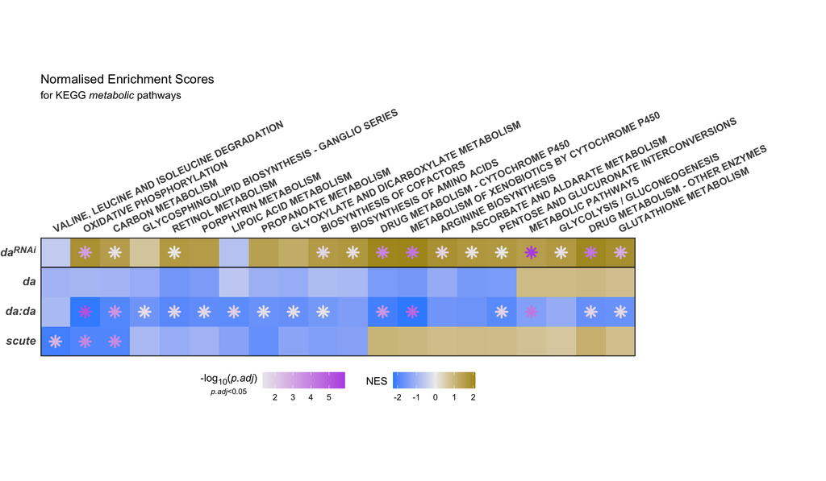

```r
gse_list <- list(scOE_gse_kmet, dadaOE_gse_kmet, daOE_gse_kmet, daKD_gse_kmet)
# `conditions` were defined further above
sets.as.factors <- unique(kegg.met_tidy$description)
layerhm.df <- gseCP_summarise(kegg.met_gmx, gse_list, conditions, sets.as.factors, cluster=TRUE, nsig.out = TRUE)
subt <- "for KEGG *metabolic* pathways"
p <- layer.heatmap(layerhm.df, subt)
p + geom_hline(aes(yintercept=3.5), linewidth = 0.5) +
  theme(plot.margin = margin(r = 200))
```

```r
ggsave(file.path(figdir, 'metabolicKEGG.pdf'))
```